# 1 Introduction

## 1.1 Project Aims

The aim of this course work project is to create the best neural network to correctly classify a dataset consisting of 100 different classes of images. The previous coursework was limited to dense and dropout layers while this project will be able to apply the use of more advanced techniques. Convolutional neural networks will be trained and tuned as well as the use of transfer learning will be applied to this problem.

## 1.2 Dataset Information

The problem for this project is to correctly classify the images from the cifar100 dataset (1). This dataset consists of 100 different classes of images with each class having 500 images for training and 100 left for testing. This is a balanced dataset with a total of 60,000 images that are 32x32 color images.

Dataset Link

## 1.3 Evaluation

The choice of an appropriate evaluation metric is dependent on the makeup of the dataset itself. This is a perfectly balanced dataset with each of the 100 classes having 600 occurrences. The use of accuracy or the area under the receiver operating characteristic curve would be appropriate for this particular dataset. Accuracy will be used in this case because it is an easier metric to understand for stakeholders who may be unfamiliar with data science terms and statistics.

A commonsense baseline accuracy can be determined by the breakdown of the number of classes. In this case there are 100 evenly balanced classes. A random guess of the same class would be able to guess the correct result 1% of the time. A neural network classifier would need to be able to produce an accuracy better than this in order to conclude that the dataset does indeed contain sufficient information.

This dataset is already split into a test and training dataset. The holdout test set contains 10,000 images, 100 of each class. The training set contains 500 images of each class for a total of 50,000 images. In order to tune a neural network classifier, the training set will be split into a training set and a validation set. A 20/80 split will be used with 20% of the training data being held out for validation. For each class of image, 400 will be used for training, 100 for validation, and a final 100 for the test set. Once the final network has been tuned and trained using the training and validation data, the model will be reinitialized with the validation data included before being tested on the test set. This will produce the final accuracy for our model for which to compare to the common sense baseline.

1 - Learning Multiple Layers of Features from Tiny Images, Alex Krizhevsky, 2009

```python
import keras
from keras.callbacks import CSVLogger
from tensorflow.keras import models, layers
import numpy as np
import pandas as pd
import matplotlib.pyplot as plt
from tensorflow.keras import layers
```

# 2 Model Development

Download Dataset

```python
from tensorflow.keras.datasets import cifar100
```

```python
(train_images_og, train_labels_og), (test_images_og, test_labels_og) = cifar100.load_data()
```

```
Downloading data from https://www.cs.toronto.edu/~kriz/cifar-100-python.tar.gz
```

```python
print('tensor shape')
print('\ttraining images:', train_images_og.shape)
print('\ttraining labels:', train_labels_og.shape)
print('\ttraining images:', train_images_og.dtype)
print('\ttraining labels:', train_labels_og.dtype)
print('\ttest images:', test_images_og.shape)
print('\ttest labels:', test_labels_og.shape)
```

```
tensor shape
	training images: (50000, 32, 32, 3)
	training labels: (50000, 1)
	training images: uint8
	training labels: int64
	test images: (10000, 32, 32, 3)
	test labels: (10000, 1)
```

## 2.1 Data Examination

The dataset consists of images that are 32x32 color images (red, green, blue) resulting in tensor shapes of 32x32x3. There are 50,000 training images and 10,000 test images. The class labels are currently integer encoded, each label is an integer ranging from 0 to 99.

### Show Samples

[figure not shown]

```python
def show_samples(data, labels):
    plt.subplots(figsize=(10, 10))
    for i in range(12):
        plt.subplot(3, 4, i+1)
        k = np.random.randint(0, data.shape[0])
        plt.title(labels[k])
        plt.imshow(data[k])
    plt.tight_layout()
    plt.show()

show_samples(train_images_og, train_labels_og)
```

## 2.2 Preprocess Data

#### One-Hot Encode Labels

```python
from tensorflow.keras.utils import to_categorical

train_labels = to_categorical(train_labels_og)
test_labels = to_categorical(test_labels_og)
```

# 3 Baseline Model

The last coursework was able to achieve an accuarcy of 25% on the cifar100 dataset while being restricted to the use of dense and dropout layers. The network consisted of 3 dense layers of 1024 units and a final 100 unit softmax output layer to match the 100 label classifications. The Adama optimizer was used with a learning rate of 1e-4. This previous model will serve as the baseline network. This will setup a good experiment to determine whether the use of convolutional layers and advanced computer vision techniques can improve upon the limited neural network constructed for the previous coursework.

#### Reshape Image Inputs for CW1 Network Baseline Model

Manually reshaping and rescaling the inputs for the previous coursework model is done to replicate results. When training new models for this coursework the use of the rescaling layer will be used.

```python
train_images = train_images_og.reshape((50000, 32, 32, 3))
test_images = test_images_og.reshape((10000, 32, 32, 3))
```

```python
train_images_flat = train_images_og.reshape((50000, 32*32*3)).astype('float32') / 255.
test_images_flat = test_images_og.reshape((10000, 32*32*3)).astype('float32') / 255.
```

```python
base_model = models.Sequential()

#first layer - needs input_shape
base_model.add(layers.Dense(1024, activation='relu', input_shape=(32 * 32 * 3, )))


# middle layers
base_model.add(layers.Dense(1024, activation='relu'))
base_model.add(layers.Dense(1024, activation='relu'))

# output layer
base_model.add(layers.Dense(100, activation='softmax'))

#
base_model.compile(optimizer=keras.optimizers.Adam(0.0001),
            loss='categorical_crossentropy',
            metrics=['accuracy'])

base_model_history = base_model.fit(
    train_images_flat,
    train_labels,
    epochs=12,
    verbose=2,
    validation_split=0.2
)
```

```python
print('Base Model Validation Accuracy: ', round(base_model_history.history['val_accuracy'][-1]*100,5),'%')
```

```
Base Model Validation Accuracy:  24.74 %
```

# 4 Custom Network Development

The following section will examine different combinations of layers, units and hyperparameters to determine the best network possible for this task. A small initial convolutional network will be trained to establish a baseline CNN accuracy. From there, the addition and removal of layers and units, the tuning of hyperparameters, will all be experimented to build a robust model that overfits the data. Then the model network will be further tuned to reduce overfitting of the data through various techniques such as dropout layers, max pooling layers, and data augmentation.

### 4.1 Develop a Small Base CNN (1)

The first model will exmine the effectiveness of a small base convolution neural network with a small number of filters. A standard window size of 3x3 with as stride of 1 will be used with no maxpooling layers included.

```python
def build_model_1():
    inputs = keras.Input(shape=(32, 32, 3))
    x = layers.Rescaling(1./255)(inputs)
    x = layers.Conv2D(filters=16, kernel_size=3, activation="relu", padding='same')(x)
    x = layers.Conv2D(filters=32, kernel_size=3, activation="relu", padding='same')(x)
    x = layers.Flatten()(x)
    outputs = layers.Dense(100, activation="softmax")(x)
    model = keras.Model(inputs=inputs, outputs=outputs)
    return model

model_1 = build_model_1()
```

```python
model_1.compile(
    optimizer=keras.optimizers.Adam(1e-4),
    loss = 'categorical_crossentropy',
    metrics=['accuracy'],
)

history_1 = model_1.fit(
    train_images,
    train_labels,
    epochs=40,
    verbose=2,
    validation_split=0.2
)
```

```python
get_max_acc_min_loss_epoch(history_1, 'Model 1 - Base Convnet ')
```

```
Model 1 - Base Convnet
Max Validation Accuracy:  29.599999999999998 %	 Num Epoch:  8
Min Validation Loss:  3.05642 		 Num Epoch:  4
```

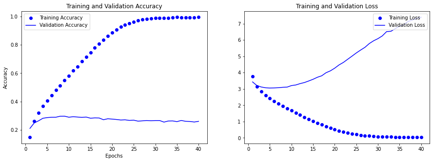

```python
plot_val_loss_acc(history_1)
```

#### Training and Validation Accuracy and Loss Plot Comparisions

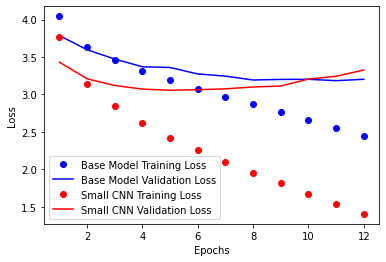

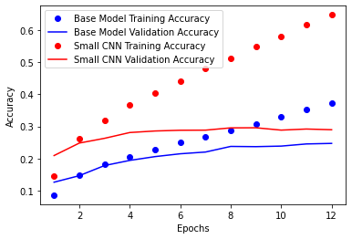

```
(None, None)
```

```python
compare_loss_acc(base_model_history, history_1, 'Base Model', 'Small CNN')
```

### 4.2 Add Max Pooling Layers to Conv2D layers

Maxpooling layers can help to reduce the number of paratemers a model can train. This can reduce overfitting. It also allows smaller windows in the final layers to be able to look at increasingly large windows of the image to help learn different features. A standard 2x2 window will be used effectively reducing the filter sizes in half.

```python
def build_model_2():
    inputs = keras.Input(shape=(32, 32, 3))
    x = layers.Rescaling(1./255)(inputs)

    x = layers.Conv2D(filters=16, kernel_size=3, activation="relu", padding='same')(x)
    x = layers.MaxPooling2D(2)(x)

    x = layers.Conv2D(filters=32, kernel_size=3, activation="relu", padding='same')(x)
    x = layers.MaxPooling2D(2)(x)

    x = layers.Conv2D(filters=64, kernel_size=3, activation="relu", padding='same')(x)

    x = layers.Flatten()(x)
    outputs = layers.Dense(100, activation="softmax")(x)
    model = keras.Model(inputs=inputs, outputs=outputs)
    return model

model_2 = build_model_2()
```

```python
model_2.compile(
    optimizer=keras.optimizers.Adam(1e-4),
    loss = 'categorical_crossentropy',
    metrics=['accuracy'],

)

history_2 = model_2.fit(
    train_images,
    train_labels,
    epochs=40,
    verbose=2,
    validation_split=0.2
)
```

```python
get_max_acc_min_loss_epoch(history_2, 'Model 2')
```

```
Model 2
Max Validation Accuracy:  36.43 %	 Num Epoch:  32
Min Validation Loss:  2.70275 		 Num Epoch:  18
```

[figure not shown]

[figure not shown]

```
(None, None)
```

```python
compare_loss_acc(history_1, history_2, 'Model 2', 'Max Pool')
```

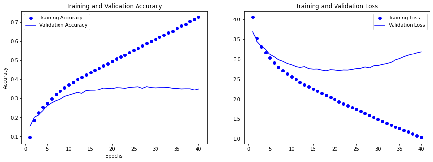

```python
plot_val_loss_acc(history_2)
```

### 4.3 Add Dense Layer (3)

The addition of a dense layer after the convolutional layers can be used to aid the network in learning more about the image patterns that have been discovered through the convolutional filters.

```python
def build_model_3(units=128):
    inputs = keras.Input(shape=(32, 32, 3))
    x = layers.Rescaling(1./255)(inputs)

    x = layers.Conv2D(filters=16, kernel_size=3, activation="relu", padding='same')(x)
    x = layers.MaxPooling2D(2)(x)

    x = layers.Conv2D(filters=32, kernel_size=3, activation="relu", padding='same')(x)
    x = layers.MaxPooling2D(2)(x)

    x = layers.Conv2D(filters=64, kernel_size=3, activation="relu", padding='same')(x)

    x = layers.Flatten()(x)
    x = layers.Dense(units, activation='relu')(x)
    outputs = layers.Dense(100, activation="softmax")(x)

    model = keras.Model(inputs=inputs, outputs=outputs)
    return model

model_3 = build_model_3()
```

```python
model_3.compile(
    optimizer=keras.optimizers.Adam(1e-4),
    loss = 'categorical_crossentropy',
    metrics=['accuracy'],
)

history_3 = model_3.fit(
    train_images,
    train_labels,
    epochs=40,
    verbose=2,
    validation_split=0.2
)
```

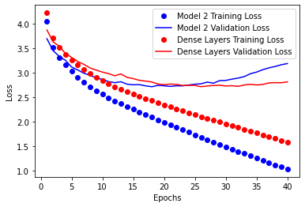

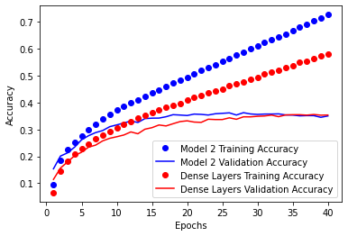

```
(None, None)
```

```python
compare_loss_acc(history_2, history_3, 'Model 2', 'Dense Layers')
```

```python
model_3a = build_model_3(256)
model_3a.compile(
    optimizer=keras.optimizers.Adam(1e-4),
    loss = 'categorical_crossentropy',
    metrics=['accuracy'],
)

history_3a = model_3a.fit(
    train_images,
    train_labels,
    epochs=40,
    verbose=2,
    validation_split=0.2
)
```

```python
model_3b = build_model_3(64)
model_3b.compile(
    optimizer=keras.optimizers.Adam(1e-4),
    loss = 'categorical_crossentropy',
    metrics=['accuracy'],
)

history_3b = model_3b.fit(
    train_images,
    train_labels,
    epochs=100,
    verbose=2,
    validation_split=0.2
)
```

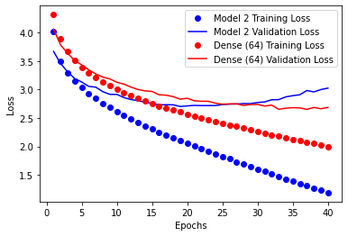

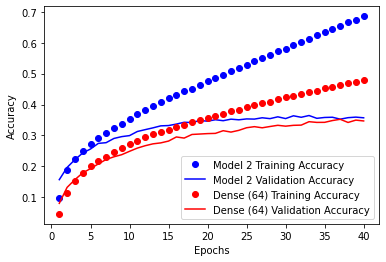

```
(None, None)
```

```python
ompare_loss_acc(history_2, history_3b, 'Model 2', 'Dense (64)')
```

```python
get_max_acc_min_loss_epoch(history_3, 'Model 3')
get_max_acc_min_loss_epoch(history_3a, 'Model 3a')
get_max_acc_min_loss_epoch(history_3b, 'Model 3b')
```

```
Model 3
Max Validation Accuracy:  35.56 %	 Num Epoch:  37
Min Validation Loss:  2.71195 		 Num Epoch:  25
Model 3a
Max Validation Accuracy:  35.91 %	 Num Epoch:  21
Min Validation Loss:  2.68028 		 Num Epoch:  17
Model 3b
Max Validation Accuracy:  36.04 %	 Num Epoch:  48
Min Validation Loss:  2.6526 		 Num Epoch:  36
```

### 4.4 Add Conv2D and MaxPooling Layer (4)

Test whether the addition of another convolutional and max pooling layer is needed to learn more patterns.

```python
def build_model_4():
    inputs = keras.Input(shape=(32, 32, 3))
    x = layers.Rescaling(1./255)(inputs)

    x = layers.Conv2D(filters=16, kernel_size=3, activation="relu", padding='same')(x)
    x = layers.MaxPooling2D(2)(x)

    x = layers.Conv2D(filters=32, kernel_size=3, activation="relu", padding='same')(x)
    x = layers.MaxPooling2D(2)(x)

    x = layers.Conv2D(filters=64, kernel_size=3, activation="relu", padding='same')(x)
    x = layers.MaxPooling2D(2)(x)

    x = layers.Conv2D(filters=128, kernel_size=3, activation="relu", padding='same')(x)
    x = layers.Flatten()(x)

    x = layers.Dense(64, activation='relu')(x)
    outputs = layers.Dense(100, activation="softmax")(x)

    model = keras.Model(inputs=inputs, outputs=outputs)
    return model

model_4 = build_model_4()
```

```python
model_4.compile(
    optimizer=keras.optimizers.Adam(1e-4),
    loss = 'categorical_crossentropy',
    metrics=['accuracy'],
)

history_4 = model_4.fit(
    train_images,
    train_labels,
    epochs=40,
    verbose=2,
    validation_split=0.2
)
```

```
Model 4: 4 Conv2D Layers
Max Validation Accuracy:  34.39 %	 Num Epoch:  37
Min Validation Loss:  2.6977 		 Num Epoch:  38
```

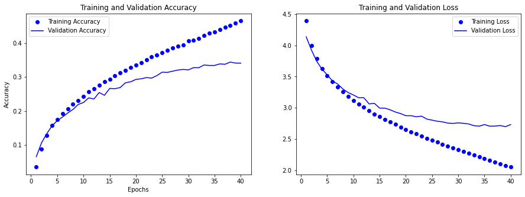

```python
get_max_acc_min_loss_epoch(history_4, 'Model 4: 4 Conv2D Layers')
plot_val_loss_acc(history_4)
```

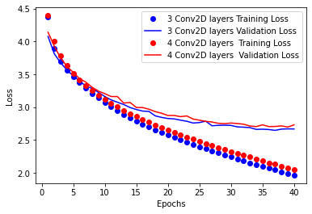

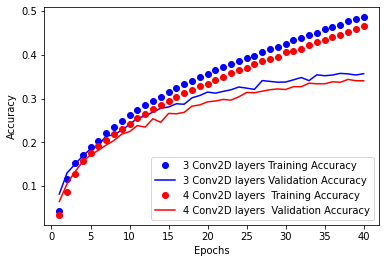

```
(None, None)
```

```python
compare_loss_acc(history_3b, history_4, '3 Conv2D layers', '4 Conv2D layers ')
```

### 4.5 Kernal size 4 (5)

Increasing the size of the windows used in the convolutional layer has the effect of the layers learning larger patterns.

```python
def build_model_5():
    inputs = keras.Input(shape=(32, 32, 3))
    x = layers.Rescaling(1./255)(inputs)

    x = layers.Conv2D(filters=16, kernel_size=4, activation="relu", padding='same')(x)
    x = layers.MaxPooling2D(2)(x)

    x = layers.Conv2D(filters=32, kernel_size=4, activation="relu", padding='same')(x)
    x = layers.MaxPooling2D(2)(x)

    x = layers.Conv2D(filters=64, kernel_size=4, activation="relu", padding='same')(x)

    x = layers.Flatten()(x)
    x = layers.Dense(64, activation='relu')(x)
    outputs = layers.Dense(100, activation="softmax")(x)

    model = keras.Model(inputs=inputs, outputs=outputs)
    return model

model_5 = build_model_5()
```

```python
model_5.compile(
    optimizer=keras.optimizers.Adam(1e-4),
    loss = 'categorical_crossentropy',
    metrics=['accuracy'],
)

history_5 = model_5.fit(
    train_images,
    train_labels,
    epochs=40,
    verbose=2,
    validation_split=0.2
)
```

```
Model 5: Conv2D 4x4 Kernal
Max Validation Accuracy:  34.69 %	 Num Epoch:  39
Min Validation Loss:  2.72545 		 Num Epoch:  33
```

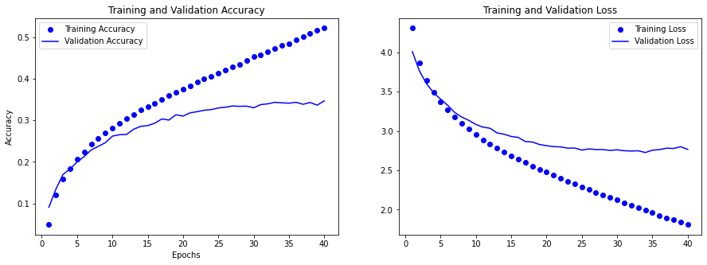

```python
get_max_acc_min_loss_epoch(history_5, 'Model 5: Conv2D 4x4 Kernal')
plot_val_loss_acc(history_5)
```

The increase in window (kernal) size results in a model that begins overfitting sooner and the maximum validation accuarcy slightly decreases as well so the 3x3 kernal size is deemed a better fit.

### 4.6 Higher and Lower Learning Rates (6,7)

Experiment to determine the optimal learning rate. A learning rate that is too high could miss a proper fit during the gradient descent algorithm. A learning rate that is too low could be too slow to learn and result in a stalled out learning process.

```python
model_6 = build_model_3(64)

model_6.compile(
    optimizer=keras.optimizers.Adam(1e-3),
    loss = 'categorical_crossentropy',
    metrics=['accuracy'],
)

history_6 = model_6.fit(
    train_images,
    train_labels,
    epochs=40,
    verbose=2,
    validation_split=0.2
)
```

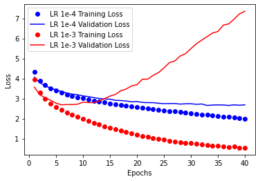

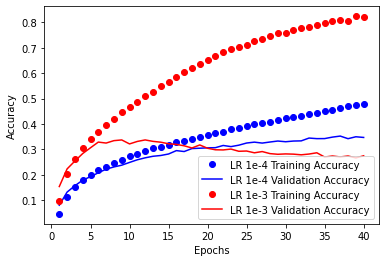

```
(None, None)
```

```python
compare_loss_acc(history_3b, history_6, 'LR 1e-4', 'LR 1e-3')
```

```python
model_7 = build_model_3(64)

model_7.compile(
    optimizer=keras.optimizers.Adam(5e-5),
    loss = 'categorical_crossentropy',
    metrics=['accuracy'],
)

history_7 = model_7.fit(
    train_images,
    train_labels,
    epochs=100,
    verbose=2,
    validation_split=0.2
)
```

[figure not shown]

[figure not shown]

```
(None, None)
```

```python
compare_loss_acc(history_3b, history_7, 'LR 1e-4', 'LR 1e-5')
```

```python
get_max_acc_min_loss_epoch(history_6, 'Model 6: Learning Rate 1e-3')
get_max_acc_min_loss_epoch(history_7, 'Model 7: Learning Rate 5e-5')
get_max_acc_min_loss_epoch(history_3b, 'Model 3b: Learning Rate 1e-4')
```

```
Model 6: Learning Rate 1e-3
Max Validation Accuracy:  33.69 %	 Num Epoch:  8
Min Validation Loss:  2.68612 		 Num Epoch:  5
Model 7: Learning Rate 5e-5
Max Validation Accuracy:  35.61 %	 Num Epoch:  98
Min Validation Loss:  2.71329 		 Num Epoch:  74
Model 3b: Learning Rate 1e-4
Max Validation Accuracy:  36.04 %	 Num Epoch:  48
Min Validation Loss:  2.6526 		 Num Epoch:  36
```

The higher learning rate of 1e-3 appears to reach its peak accuracy too soon. This is the risk of increasing the learning rate too high, it may skips over the optimum fit and begins overfitting without finding the optimum minumum. The lower learning rate trained much more slowly as expected. It took around 75 epochs to begin overfitting but the minumum loss was still greater than that of the learning rate 1e-4. The original learning rate is still the best candidate.

### 4.7 Increase Starting Filter Sizes (8)

Increasing the amount of filters used in each convolutional layer could allow the network to learn more patterns in the data and increase overall accuracy. However, too many and this could lead to overfitting.

```python
def build_model_8():
    inputs = keras.Input(shape=(32, 32, 3))
    x = layers.Rescaling(1./255)(inputs)

    x = layers.Conv2D(filters=32, kernel_size=3, activation="relu", padding='same')(x)
    x = layers.MaxPooling2D(2)(x)

    x = layers.Conv2D(filters=64, kernel_size=3, activation="relu", padding='same')(x)
    x = layers.MaxPooling2D(2)(x)

    x = layers.Conv2D(filters=128, kernel_size=3, activation="relu", padding='same')(x)

    x = layers.Flatten()(x)
    x = layers.Dense(64, activation='relu')(x)
    outputs = layers.Dense(100, activation="softmax")(x)

    model = keras.Model(inputs=inputs, outputs=outputs)
    return model

model_8 = build_model_8()
```

```python
model_8.compile(
    optimizer=keras.optimizers.Adam(1e-4),
    loss = 'categorical_crossentropy',
    metrics=['accuracy'],
)

history_8 = model_8.fit(
    train_images,
    train_labels,
    epochs=50,
    verbose=2,
    validation_split=0.2
)
```

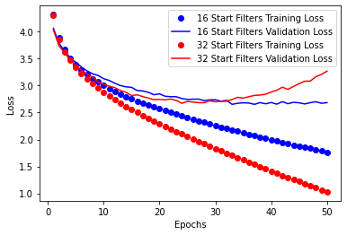

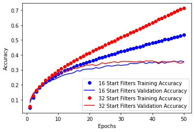

```
(None, None)
```

```python
compare_loss_acc(history_3b, history_8, '16 Start Filters','32 Start Filters')
```

```python
def build_model_8b():
    inputs = keras.Input(shape=(32, 32, 3))
    x = layers.Rescaling(1./255)(inputs)

    x = layers.Conv2D(filters=128, kernel_size=3, activation="relu", padding='same')(x)
    x = layers.MaxPooling2D(2)(x)

    x = layers.Conv2D(filters=256, kernel_size=3, activation="relu", padding='same')(x)
    x = layers.MaxPooling2D(2)(x)

    x = layers.Conv2D(filters=512, kernel_size=3, activation="relu", padding='same')(x)

    x = layers.Flatten()(x)
    x = layers.Dense(64, activation='relu')(x)
    outputs = layers.Dense(100, activation="softmax")(x)

    model = keras.Model(inputs=inputs, outputs=outputs)
    return model

model_8b = build_model_8b()
```

```python
model_8b.compile(
    optimizer=keras.optimizers.Adam(1e-4),
    loss = 'categorical_crossentropy',
    metrics=['accuracy'],
)

history_8b = model_8b.fit(
    train_images,
    train_labels,
    epochs=50,
    verbose=2,
    validation_split=0.2
)
```

[output not shown]

[figure not shown]

[figure not shown]

[output not shown]

```python
def build_model_8c():
    inputs = keras.Input(shape=(32, 32, 3))
    x = layers.Rescaling(1./255)(inputs)

    x = layers.Conv2D(filters=128, kernel_size=3, activation="relu", padding='same')(x)
    x = layers.MaxPooling2D(2)(x)

    x = layers.Conv2D(filters=256, kernel_size=3, activation="relu", padding='same')(x)
    x = layers.MaxPooling2D(2)(x)

    x = layers.Conv2D(filters=512, kernel_size=3, activation="relu", padding='same')(x)

    x = layers.Flatten()(x)
    x = layers.Dense(128, activation='relu')(x)
    outputs = layers.Dense(100, activation="softmax")(x)

    model = keras.Model(inputs=inputs, outputs=outputs)
    return model

model_8c = build_model_8c()
```

```python
model_8c.compile(
    optimizer=keras.optimizers.Adam(1e-4),
    loss = 'categorical_crossentropy',
    metrics=['accuracy'],
)

history_8c = model_8c.fit(
    train_images,
    train_labels,
    epochs=50,
    verbose=2,
    validation_split=0.2
)
```

```python
def build_model_8d():
    inputs = keras.Input(shape=(32, 32, 3))
    x = layers.Rescaling(1./255)(inputs)

    x = layers.Conv2D(filters=128, kernel_size=3, activation="relu", padding='same')(x)
    x = layers.MaxPooling2D(2)(x)

    x = layers.Conv2D(filters=256, kernel_size=3, activation="relu", padding='same')(x)
    x = layers.MaxPooling2D(2)(x)

    x = layers.Conv2D(filters=512, kernel_size=3, activation="relu", padding='same')(x)

    x = layers.Flatten()(x)
    x = layers.Dense(256, activation='relu')(x)
    outputs = layers.Dense(100, activation="softmax")(x)

    model = keras.Model(inputs=inputs, outputs=outputs)
    return model

model_8d = build_model_8d()
```

```python
model_8d.compile(
    optimizer=keras.optimizers.Adam(1e-4),
    loss = 'categorical_crossentropy',
    metrics=['accuracy'],
)

history_8d = model_8d.fit(
    train_images,
    train_labels,
    epochs=50,
    verbose=2,
    validation_split=0.2
)
```

```python
get_max_acc_min_loss_epoch(history_8b, 'Model 8b: Layer 1 128 Filters - Dense 64')
get_max_acc_min_loss_epoch(history_8, 'Model 8a: Layer 1 64 Filters - Dense 64')
get_max_acc_min_loss_epoch(history_8c, 'Model 8c: Layer 1 64 Filters - Dense 128')
get_max_acc_min_loss_epoch(history_8d, 'Model 8d: Layer 1 128 Filters - Dense 256')
```

[output not shown]

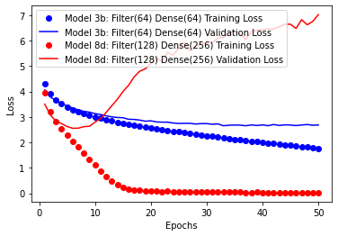

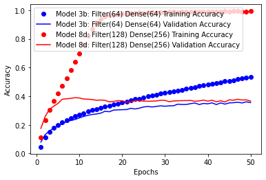

```
(None, None)
```

```python
compare_loss_acc(history_3b, history_8d, 'Model 3b: Filter(64) Dense(64)', 'Model 8d: Filter(128) Dense(256)')
```

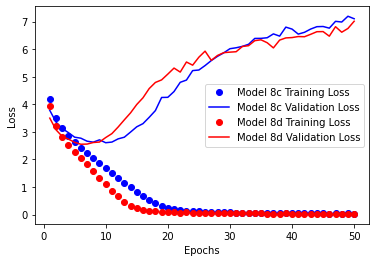

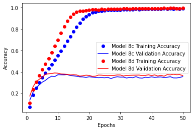

```
(None, None)
```

```python
compare_loss_acc(history_8c, history_8d, 'Model 8c', 'Model 8d')
```

```python
def build_model_8e():
    inputs = keras.Input(shape=(32, 32, 3))
    x = layers.Rescaling(1./255)(inputs)

    x = layers.Conv2D(filters=256, kernel_size=3, activation="relu", padding='same')(x)
    x = layers.MaxPooling2D(2)(x)

    x = layers.Conv2D(filters=512, kernel_size=3, activation="relu", padding='same')(x)
    x = layers.MaxPooling2D(2)(x)

    x = layers.Conv2D(filters=1024, kernel_size=3, activation="relu", padding='same')(x)

    x = layers.Flatten()(x)
    x = layers.Dense(512, activation='relu')(x)
    outputs = layers.Dense(100, activation="softmax")(x)

    model = keras.Model(inputs=inputs, outputs=outputs)
    return model

model_8e = build_model_8e()
```

```python
model_8e.compile(
    optimizer=keras.optimizers.Adam(1e-4),
    loss = 'categorical_crossentropy',
    metrics=['accuracy'],
)

history_8e = model_8e.fit(
    train_images,
    train_labels,
    epochs=25,
    verbose=2,
    validation_split=0.2
)
```

```
Model 8d: Layer 1 128 Filters - Dense 256
Max Validation Accuracy:  38.97 %	 Num Epoch:  8
Min Validation Loss:  2.55309 		 Num Epoch:  5
Model 8e: Layer 1 256 Filters - Dense 512
Max Validation Accuracy:  40.839999999999996 %	 Num Epoch:  6
Min Validation Loss:  2.52209 		 Num Epoch:  4
```

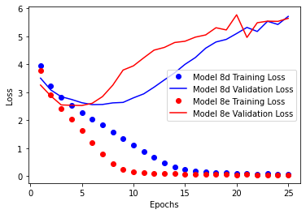

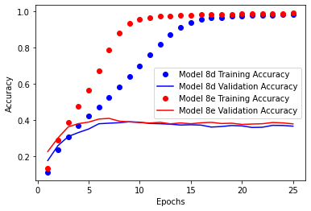

```
(None, None)
```

```python
get_max_acc_min_loss_epoch(history_8d, 'Model 8d: Layer 1 128 Filters - Dense 256')
get_max_acc_min_loss_epoch(history_8e, 'Model 8e: Layer 1 256 Filters - Dense 512')
compare_loss_acc(history_8d, history_8e, 'Model 8d', 'Model 8e')
```

Increasing the starting filter size to 256 and dense layer units to 512 did again increase the validation accuracy and reduce the validation loss. The bigger the size of filters and units, the quicker the model achievens overfitting.